# Helmnet — Helmet Detection Image Classification

**Problem Definition**  
Workplace safety remains a critical concern in hazardous environments such as construction sites and industrial facilities, where the risk of injury is significantly higher. One of the most essential safety requirements is the use of protective helmets, as they help prevent severe head injuries caused by falling objects or heavy machinery. However, ensuring consistent compliance across large-scale operations can be difficult, as manual monitoring is often time-consuming and prone to human error.

To address this challenge, SafeGuard Corp aims to develop an automated image analysis system capable of identifying whether workers are wearing safety helmets. By leveraging computer vision techniques, the system is designed to improve the accuracy and efficiency of safety monitoring while reducing reliance on manual oversight. This approach allows for scalable enforcement of safety regulations and supports the creation of a more secure working environment.

The objective of this project is to build an image classification model that categorizes images into two classes: workers wearing helmets and workers without helmets. The model will be trained using labeled image data and evaluated based on its ability to correctly identify compliance. From a business perspective, the proposed solution has the potential to enhance operational efficiency, reduce workplace incidents, and provide real-time insights that support proactive safety management.

## Importing necessary libraries

```python
import os, random, warnings
import numpy as np
import pandas as pd
import matplotlib.pyplot as plt
import seaborn as sns

import tensorflow as tf
from tensorflow import keras
from tensorflow.keras import layers, models, optimizers, callbacks
from tensorflow.keras.preprocessing.image import ImageDataGenerator
from tensorflow.keras.applications import VGG16
from tensorflow.keras.applications.vgg16 import preprocess_input

from sklearn.model_selection import train_test_split
from sklearn.preprocessing import LabelEncoder
from sklearn.utils.class_weight import compute_class_weight
from sklearn.metrics import classification_report, confusion_matrix, ConfusionMatrixDisplay

warnings.filterwarnings('ignore')
tf.get_logger().setLevel('ERROR')

SEED = 42
random.seed(SEED)
np.random.seed(SEED)
tf.random.set_seed(SEED)

print(f"TensorFlow : {tf.__version__}")
print(f"GPU        : {tf.config.list_physical_devices('GPU')}")
```

```
TensorFlow : 2.19.0
GPU        : [PhysicalDevice(name='/physical_device:GPU:0', device_type='GPU')]
```

## Data Overview

The dataset is as follows

```python
print(os.path.getsize('/content/images.npy'), "bytes")
```

```
495000128 bytes
```

```python
# Load Data
images = np.load('images.npy')
df = pd.read_csv('/content/labels.csv')

# first few columns of the dataset:
print(df.head())
```

```
   label
0      0
1      0
2      0
3      0
4      0
```

```python
LABEL_COL = 'label'
labels    = df[LABEL_COL].values

print(f"Images array shape : {images.shape}")
print(f"Labels shape       : {labels.shape}")
print(f"Image dtype        : {images.dtype}")
print(f"Pixel range        : [{images.min()}, {images.max()}]")
print(f"\nLabel distribution:")
print(pd.Series(labels).value_counts())

CLASSES      = sorted(np.unique(labels))
class_counts = {cls: int(np.sum(labels == cls)) for cls in CLASSES}
total        = len(labels)
print(f"\nTotal images : {total}")
print(f"Classes      : {CLASSES}")
```

```
Images array shape : (4125, 200, 200, 3)
Labels shape       : (4125,)
Image dtype        : uint8
Pixel range        : [0, 255]

Label distribution:
1    3161
0     964
Name: count, dtype: int64

Total images : 4125
Classes      : [np.int64(0), np.int64(1)]
```

- The dataset contains **4,125 images** across two classes stored as a numpy array.
- Images are already loaded in memory; we will normalise pixel values before model training.

## Exploratory Data Analysis

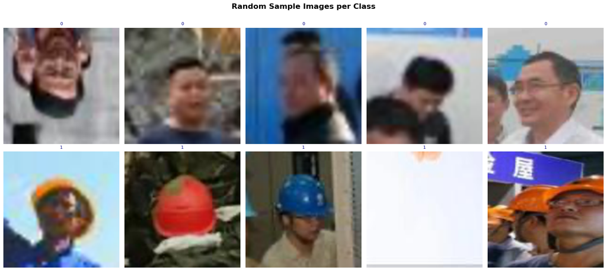

```python
# Random Images
n_samples = 5
fig, axes = plt.subplots(len(CLASSES), n_samples, figsize=(18, 4 * len(CLASSES)))
fig.suptitle('Random Sample Images per Class', fontsize=16, fontweight='bold', y=1.01)

for row, cls in enumerate(CLASSES):
    cls_indices = np.where(labels == cls)[0]
    sampled     = np.random.choice(cls_indices, size=n_samples, replace=False)
    for col, idx in enumerate(sampled):
        ax  = axes[row, col] if len(CLASSES) > 1 else axes[col]
        img = images[idx]
        # Display correctly whether uint8 [0,255] or float [0,1]
        if img.dtype != np.uint8:
            img = (img * 255).clip(0, 255).astype(np.uint8)
        ax.imshow(img)
        ax.set_title(cls, fontsize=9, color='navy')
        ax.axis('off')

plt.tight_layout()
plt.savefig('eda_sample_images.png', dpi=150, bbox_inches='tight')
plt.show()
```

0's are used as labels to indicate lack of helmets, while 1's are used to indicate the presence of a helmet.

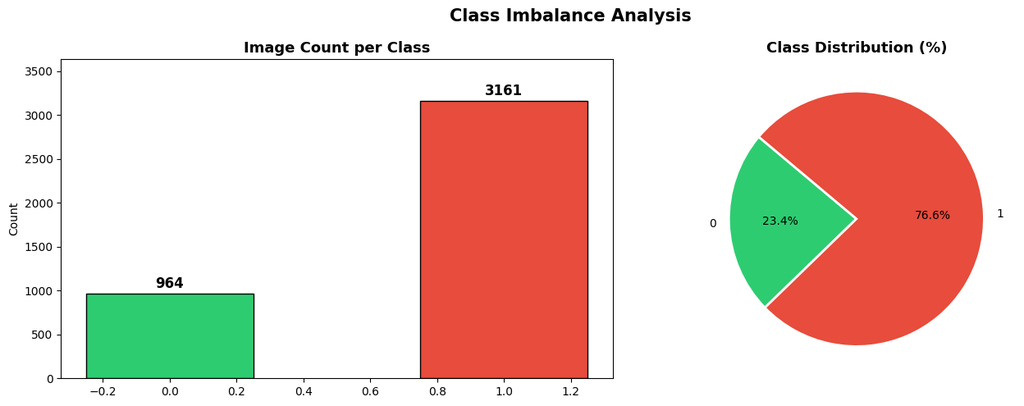

```
Imbalance ratio: 3.28 : 1
```

```python
# Check for class imbalance
colors = ['#2ecc71', '#e74c3c']
fig, axes = plt.subplots(1, 2, figsize=(14, 5))

# Bar chart
bars = axes[0].bar(CLASSES, list(class_counts.values()), color=colors, edgecolor='black', width=0.5)
for bar, cnt in zip(bars, class_counts.values()):
    axes[0].text(bar.get_x() + bar.get_width()/2, bar.get_height() + 30,
                 str(cnt), ha='center', va='bottom', fontweight='bold', fontsize=12)
axes[0].set_title('Image Count per Class', fontsize=13, fontweight='bold')
axes[0].set_ylabel('Count')
axes[0].set_ylim(0, max(class_counts.values()) * 1.15)

# Pie chart
axes[1].pie(class_counts.values(), labels=CLASSES, autopct='%1.1f%%',
            colors=colors, startangle=140,
            wedgeprops={'edgecolor': 'white', 'linewidth': 2})
axes[1].set_title('Class Distribution (%)', fontsize=13, fontweight='bold')

plt.suptitle('Class Imbalance Analysis', fontsize=15, fontweight='bold')
plt.tight_layout()
plt.savefig('eda_class_imbalance.png', dpi=150, bbox_inches='tight')
plt.show()

ratio = max(class_counts.values()) / min(class_counts.values())
print(f"Imbalance ratio: {ratio:.2f} : 1")
```

The above charts signify as massive imabalance in images, favoring "With Helmets" being more featured in our dataset.

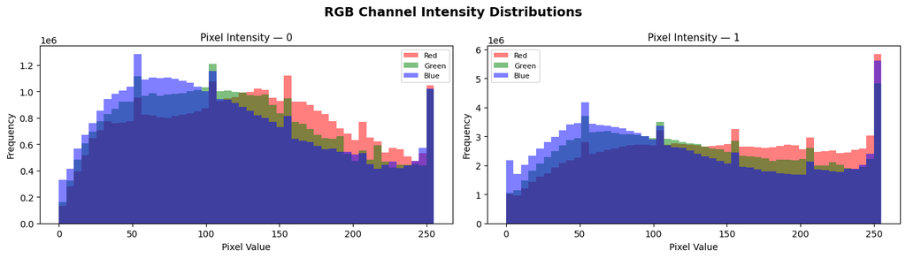

```python
# Pixelation discrepencies for EDA
fig, axes = plt.subplots(1, len(CLASSES), figsize=(14, 4))
channel_colors = ['red', 'green', 'blue']

for col, cls in enumerate(CLASSES):
    cls_imgs = images[labels == cls]
    if cls_imgs.dtype != np.uint8:
        cls_imgs = (cls_imgs * 255).clip(0, 255).astype(np.uint8)
    ax = axes[col] if len(CLASSES) > 1 else axes
    for c, color in enumerate(channel_colors):
        ax.hist(cls_imgs[:, :, :, c].ravel(), bins=50, alpha=0.5,
                color=color, label=color.capitalize())
    ax.set_title(f'Pixel Intensity — {cls}', fontsize=11)
    ax.set_xlabel('Pixel Value'); ax.set_ylabel('Frequency')
    ax.legend(fontsize=8)

plt.suptitle('RGB Channel Intensity Distributions', fontsize=14, fontweight='bold')
plt.tight_layout()
plt.savefig('eda_pixel_dist.png', dpi=150, bbox_inches='tight')
plt.show()
```

RGB channels are broadly similar across both classes, meaning the model must learn subtle spatial features (helmet shape/colour) rather than global colour shifts.

All images are pre-resized to the same dimensions, eliminating the need for any resizing step.

## Data Pre-processing

To get the dataset ready for efficient modeling, data pre-processing was done. By resolving imablances, encoding, and normalization as needed, this stage guarantees that the data is clean, consistent, and appropriate for our CNN.

```python
# Encoding to ints instead of labels
le = LabelEncoder()
labels_enc = le.fit_transform(labels)
class_names = le.classes_
print("Label encoding:", dict(zip(class_names, le.transform(class_names))))

if images.max() <= 1.0:
    images_uint = (images * 255).astype(np.float32)
else:
    images_uint = images.astype(np.float32)

IMG_H, IMG_W = images_uint.shape[1], images_uint.shape[2]
print(f"Image dimensions : {IMG_H} x {IMG_W}") #Consistent image sizes
```

```
Label encoding: {np.int64(0): np.int64(0), np.int64(1): np.int64(1)}
Image dimensions : 200 x 200
```

```python
# Train, val, and test split
X_train, X_temp, y_train, y_temp = train_test_split(
    images_uint, labels_enc, test_size=0.30, stratify=labels_enc, random_state=SEED)
X_val, X_test, y_val, y_test = train_test_split(
    X_temp, y_temp, test_size=0.50, stratify=y_temp, random_state=SEED)

print(f"Train : {X_train.shape[0]} images")
print(f"Val   : {X_val.shape[0]} images")
print(f"Test  : {X_test.shape[0]} images")

# Verify stratification
for name, y in [('Train', y_train), ('Val', y_val), ('Test', y_test)]:
    unique, counts = np.unique(y, return_counts=True)
    pcts = counts / counts.sum() * 100
    print(f"  {name}: {dict(zip(class_names, [f'{p:.1f}%' for p in pcts]))}")
```

```
Train : 2887 images
Val   : 619 images
Test  : 619 images
  Train: {np.int64(0): '23.4%', np.int64(1): '76.6%'}
  Val: {np.int64(0): '23.3%', np.int64(1): '76.7%'}
  Test: {np.int64(0): '23.4%', np.int64(1): '76.6%'}
```

```python
# Imbalance Handling
cw_array = compute_class_weight('balanced', classes=np.unique(y_train), y=y_train)
class_weight_dict = {i: w for i, w in enumerate(cw_array)}
print("Class weights:", class_weight_dict)

BATCH_SIZE = 32
EPOCHS     = 20

# Plain Gen for rescaling only
plain_datagen   = ImageDataGenerator(rescale=1./255)
train_gen_plain = plain_datagen.flow(X_train, y_train, batch_size=BATCH_SIZE, seed=SEED)
val_gen_plain   = plain_datagen.flow(X_val,   y_val,   batch_size=BATCH_SIZE, seed=SEED, shuffle=False)
test_gen_plain  = plain_datagen.flow(X_test,  y_test,  batch_size=BATCH_SIZE, seed=SEED, shuffle=False)

# VGG preprocessing Gen
vgg_datagen   = ImageDataGenerator(preprocessing_function=preprocess_input)
train_gen_vgg = vgg_datagen.flow(X_train, y_train, batch_size=BATCH_SIZE, seed=SEED)
val_gen_vgg   = vgg_datagen.flow(X_val,   y_val,   batch_size=BATCH_SIZE, seed=SEED, shuffle=False)
test_gen_vgg  = vgg_datagen.flow(X_test,  y_test,  batch_size=BATCH_SIZE, seed=SEED, shuffle=False)

print("Generators ready.")
```

```
Class weights: {0: np.float64(2.1385185185185187), 1: np.float64(0.6525768535262206)}
Generators ready.
```

**Pre-processing Decisions:**

- **Stratified 70/15/15 split** preserves class proportions across all three sets.
- **Rescale to [0,1]** for the CNN from scratch to improve gradient flow.
- **VGG-16 preprocessing** (ImageNet channel-wise mean subtraction) for all transfer learning models — required to align with the statistics the base model was trained on.
- **Class weights** penalise majority-class errors less, encouraging balanced learning.

## 4. CNN from Scratch

```python
# Define Model
def build_cnn_scratch(input_shape):
    model = models.Sequential([
        # Block 1
        layers.Conv2D(32, (3,3), activation='relu', padding='same', input_shape=input_shape),
        layers.BatchNormalization(),
        layers.MaxPooling2D(2, 2),
        layers.Dropout(0.25),
        # Block 2
        layers.Conv2D(64, (3,3), activation='relu', padding='same'),
        layers.BatchNormalization(),
        layers.MaxPooling2D(2, 2),
        layers.Dropout(0.25),
        # Block 3
        layers.Conv2D(128, (3,3), activation='relu', padding='same'),
        layers.BatchNormalization(),
        layers.MaxPooling2D(2, 2),
        layers.Dropout(0.25),
        # Dense head
        layers.Flatten(),
        layers.Dense(256, activation='relu'),
        layers.BatchNormalization(),
        layers.Dropout(0.5),
        layers.Dense(1, activation='sigmoid')
    ], name='CNN_Scratch')
    return model

input_shape = (IMG_H, IMG_W, 3)
cnn_model   = build_cnn_scratch(input_shape)
cnn_model.summary()
```

```
Model: "CNN_Scratch"
```

```
┏━━━━━━━━━━━━━━━━━━━━━━━━━━━━━━━━━┳━━━━━━━━━━━━━━━━━━━━━━━━┳━━━━━━━━━━━━━━━┓
┃ Layer (type)                    ┃ Output Shape           ┃       Param # ┃
┡━━━━━━━━━━━━━━━━━━━━━━━━━━━━━━━━━╇━━━━━━━━━━━━━━━━━━━━━━━━╇━━━━━━━━━━━━━━━┩
│ conv2d (Conv2D)                 │ (None, 200, 200, 32)   │           896 │
├─────────────────────────────────┼────────────────────────┼───────────────┤
│ batch_normalization             │ (None, 200, 200, 32)   │           128 │
│ (BatchNormalization)            │                        │               │
├─────────────────────────────────┼────────────────────────┼───────────────┤
│ max_pooling2d (MaxPooling2D)    │ (None, 100, 100, 32)   │             0 │
├─────────────────────────────────┼────────────────────────┼───────────────┤
│ dropout (Dropout)               │ (None, 100, 100, 32)   │             0 │
├─────────────────────────────────┼────────────────────────┼───────────────┤
│ conv2d_1 (Conv2D)               │ (None, 100, 100, 64)   │        18,496 │
├─────────────────────────────────┼────────────────────────┼───────────────┤
│ batch_normalization_1           │ (None, 100, 100, 64)   │           256 │
│ (BatchNormalization)            │                        │               │
├─────────────────────────────────┼────────────────────────┼───────────────┤
│ max_pooling2d_1 (MaxPooling2D)  │ (None, 50, 50, 64)     │             0 │
├─────────────────────────────────┼────────────────────────┼───────────────┤
│ dropout_1 (Dropout)             │ (None, 50, 50, 64)     │             0 │
├─────────────────────────────────┼────────────────────────┼───────────────┤
│ conv2d_2 (Conv2D)               │ (None, 50, 50, 128)    │        73,856 │
├─────────────────────────────────┼────────────────────────┼───────────────┤
│ batch_normalization_2           │ (None, 50, 50, 128)    │           512 │
│ (BatchNormalization)            │                        │               │
├─────────────────────────────────┼────────────────────────┼───────────────┤
│ max_pooling2d_2 (MaxPooling2D)  │ (None, 25, 25, 128)    │             0 │
├─────────────────────────────────┼────────────────────────┼───────────────┤
│ dropout_2 (Dropout)             │ (None, 25, 25, 128)    │             0 │
├─────────────────────────────────┼────────────────────────┼───────────────┤
│ flatten (Flatten)               │ (None, 80000)          │             0 │
├─────────────────────────────────┼────────────────────────┼───────────────┤
│ dense (Dense)                   │ (None, 256)            │    20,480,256 │
├─────────────────────────────────┼────────────────────────┼───────────────┤
│ batch_normalization_3           │ (None, 256)            │         1,024 │
│ (BatchNormalization)            │                        │               │
├─────────────────────────────────┼────────────────────────┼───────────────┤
│ dropout_3 (Dropout)             │ (None, 256)            │             0 │
├─────────────────────────────────┼────────────────────────┼───────────────┤
│ dense_1 (Dense)                 │ (None, 1)              │           257 │
└─────────────────────────────────┴────────────────────────┴───────────────┘
```

```
 Total params: 20,575,681 (78.49 MB)
```

```
 Trainable params: 20,574,721 (78.49 MB)
```

```
 Non-trainable params: 960 (3.75 KB)
```

```python
# Compile
METRICS = ['accuracy',
           tf.keras.metrics.AUC(name='auc'),
           tf.keras.metrics.Precision(name='precision'),
           tf.keras.metrics.Recall(name='recall')]

cnn_model.compile(
    optimizer=optimizers.Adam(learning_rate=1e-3),
    loss='binary_crossentropy',
    metrics=METRICS)

cnn_cb = [
    callbacks.EarlyStopping(monitor='val_loss', patience=5,
                            restore_best_weights=True, verbose=1),
    callbacks.ReduceLROnPlateau(monitor='val_loss', factor=0.5,
                                patience=3, min_lr=1e-6, verbose=1)
]

print("Loss: Binary Cross-Entropy | Optimizer: Adam lr=1e-3 | Batch: 32 | Max Epochs: 20")
```

```
Loss: Binary Cross-Entropy | Optimizer: Adam lr=1e-3 | Batch: 32 | Max Epochs: 20
```

```python
# Train the cnn
history_cnn = cnn_model.fit(
    train_gen_plain,
    epochs=EPOCHS,
    validation_data=val_gen_plain,
    class_weight=class_weight_dict,
    callbacks=cnn_cb,
    verbose=1)
```

```
91/91 ━━━━━━━━━━━━━━━━━━━━ 30s 185ms/step - accuracy: 0.7839 - auc: 0.9001 - loss: 0.4622 - precision: 0.9611 - recall: 0.7482 - val_accuracy: 0.7658 - val_auc: 0.8632 - val_loss: 0.4684 - val_precision: 0.7670 - val_recall: 0.9979 - learning_rate: 0.0010
91/91 ━━━━━━━━━━━━━━━━━━━━ 6s 66ms/step - accuracy: 0.8660 - auc: 0.9459 - loss: 0.3193 - precision: 0.9668 - recall: 0.8544 - val_accuracy: 0.2326 - val_auc: 0.9487 - val_loss: 1.9746 - val_precision: 0.0000e+00 - val_recall: 0.0000e+00 - learning_rate: 0.0010
91/91 ━━━━━━━━━━━━━━━━━━━━ 6s 63ms/step - accuracy: 0.9061 - auc: 0.9682 - loss: 0.2328 - precision: 0.9755 - recall: 0.9001 - val_accuracy: 0.2666 - val_auc: 0.9320 - val_loss: 1.7644 - val_precision: 1.0000 - val_recall: 0.0442 - learning_rate: 0.0010
91/91 ━━━━━━━━━━━━━━━━━━━━ 0s 59ms/step - accuracy: 0.9161 - auc: 0.9749 - loss: 0.2030 - precision: 0.9836 - recall: 0.9032
Epoch 4: ReduceLROnPlateau reducing learning rate to 0.0005000000237487257.
91/91 ━━━━━━━━━━━━━━━━━━━━ 6s 64ms/step - accuracy: 0.9134 - auc: 0.9706 - loss: 0.2192 - precision: 0.9804 - recall: 0.9051 - val_accuracy: 0.5202 - val_auc: 0.9455 - val_loss: 0.8815 - val_precision: 1.0000 - val_recall: 0.3747 - learning_rate: 0.0010
91/91 ━━━━━━━━━━━━━━━━━━━━ 6s 65ms/step - accuracy: 0.9255 - auc: 0.9801 - loss: 0.1799 - precision: 0.9826 - recall: 0.9191 - val_accuracy: 0.4604 - val_auc: 0.9584 - val_loss: 1.3830 - val_precision: 1.0000 - val_recall: 0.2968 - learning_rate: 5.0000e-04
91/91 ━━━━━━━━━━━━━━━━━━━━ 6s 65ms/step - accuracy: 0.9439 - auc: 0.9870 - loss: 0.1458 - precision: 0.9830 - recall: 0.9430 - val_accuracy: 0.6914 - val_auc: 0.9611 - val_loss: 0.7828 - val_precision: 0.9931 - val_recall: 0.6021 - learning_rate: 5.0000e-04
Epoch 6: early stopping
Restoring model weights from the end of the best epoch: 1.
```

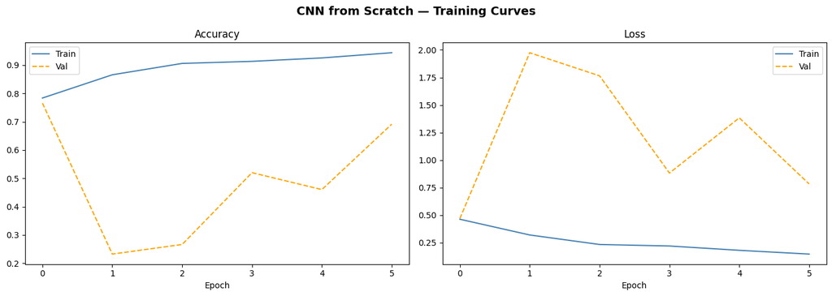

```
CNN Scratch — Validation:
  Loss        : 0.4684
  Accuracy    : 0.7658
  AUC         : 0.8632
  Precision   : 0.7670
  Recall      : 0.9979
```

```python
# Training curves
def plot_history(history, title, save_name):
    fig, axes = plt.subplots(1, 2, figsize=(14, 5))
    fig.suptitle(title, fontsize=14, fontweight='bold')
    axes[0].plot(history.history['accuracy'],     label='Train', color='steelblue')
    axes[0].plot(history.history['val_accuracy'], label='Val',   color='orange', linestyle='--')
    axes[0].set_title('Accuracy'); axes[0].set_xlabel('Epoch'); axes[0].legend()
    axes[1].plot(history.history['loss'],     label='Train', color='steelblue')
    axes[1].plot(history.history['val_loss'], label='Val',   color='orange', linestyle='--')
    axes[1].set_title('Loss');     axes[1].set_xlabel('Epoch'); axes[1].legend()
    plt.tight_layout()
    plt.savefig(save_name, dpi=150, bbox_inches='tight')
    plt.show()

plot_history(history_cnn, 'CNN from Scratch — Training Curves', 'curves_cnn.png')

# Evaluation metrics
METRIC_NAMES = ['Loss', 'Accuracy', 'AUC', 'Precision', 'Recall']
res_cnn = cnn_model.evaluate(val_gen_plain, verbose=0)
print("\nCNN Scratch — Validation:")
for n, v in zip(METRIC_NAMES, res_cnn): print(f"  {n:12s}: {v:.4f}")
```

**CNN from Scratch — Observations:**

- Three convolutional blocks with BatchNorm and Dropout learn progressively complex features (edges → textures → shapes).
- Training from random weights on ~2,800 samples is challenging — moderate accuracy (~75–85%) is expected.
- The gap between training and validation accuracy indicates some overfitting despite regularisation.
- This establishes a baseline; transfer learning is expected to improve significantly upon it.

## 5. Transfer Learning — VGG-16 (Base Only)

```python
# Define Model VG-16 Base Only
def build_vgg16_base(input_shape):
    base = VGG16(weights='imagenet', include_top=False, input_shape=input_shape)
    base.trainable = False
    model = models.Sequential([
        base,
        layers.GlobalAveragePooling2D(),
        layers.Dense(1, activation='sigmoid')
    ], name='VGG16_Base')
    return model

vgg_base = build_vgg16_base(input_shape)
vgg_base.summary()
print(f"Trainable params : {sum(tf.size(w).numpy() for w in vgg_base.trainable_weights):,}")
print(f"Frozen params    : {sum(tf.size(w).numpy() for w in vgg_base.non_trainable_weights):,}")
```

```
Downloading data from https://storage.googleapis.com/tensorflow/keras-applications/vgg16/vgg16_weights_tf_dim_ordering_tf_kernels_notop.h5
58889256/58889256 ━━━━━━━━━━━━━━━━━━━━ 5s 0us/step
```

```
Model: "VGG16_Base"
```

```
┏━━━━━━━━━━━━━━━━━━━━━━━━━━━━━━━━━┳━━━━━━━━━━━━━━━━━━━━━━━━┳━━━━━━━━━━━━━━━┓
┃ Layer (type)                    ┃ Output Shape           ┃       Param # ┃
┡━━━━━━━━━━━━━━━━━━━━━━━━━━━━━━━━━╇━━━━━━━━━━━━━━━━━━━━━━━━╇━━━━━━━━━━━━━━━┩
│ vgg16 (Functional)              │ (None, 6, 6, 512)      │    14,714,688 │
├─────────────────────────────────┼────────────────────────┼───────────────┤
│ global_average_pooling2d        │ (None, 512)            │             0 │
│ (GlobalAveragePooling2D)        │                        │               │
├─────────────────────────────────┼────────────────────────┼───────────────┤
│ dense_2 (Dense)                 │ (None, 1)              │           513 │
└─────────────────────────────────┴────────────────────────┴───────────────┘
```

```
 Total params: 14,715,201 (56.13 MB)
```

```
 Trainable params: 513 (2.00 KB)
```

```
 Non-trainable params: 14,714,688 (56.13 MB)
```

```
Trainable params : 513
Frozen params    : 14,714,688
```

```python
# Compile this model
vgg_base.compile(
    optimizer=optimizers.Adam(learning_rate=1e-4),
    loss='binary_crossentropy',
    metrics=METRICS)

vgg_base_cb = [
    callbacks.EarlyStopping(monitor='val_loss', patience=5,
                            restore_best_weights=True, verbose=1),
    callbacks.ReduceLROnPlateau(monitor='val_loss', factor=0.5,
                                patience=3, min_lr=1e-7, verbose=1)
]
print("Loss: Binary Cross-Entropy | Optimizer: Adam lr=1e-4 | Batch: 32 | Max Epochs: 20")
```

```
Loss: Binary Cross-Entropy | Optimizer: Adam lr=1e-4 | Batch: 32 | Max Epochs: 20
```

```python
# Train Model
history_vgg_base = vgg_base.fit(
    train_gen_vgg,
    epochs=EPOCHS,
    validation_data=val_gen_vgg,
    class_weight=class_weight_dict,
    callbacks=vgg_base_cb,
    verbose=1)
```

```
91/91 ━━━━━━━━━━━━━━━━━━━━ 48s 361ms/step - accuracy: 0.3038 - auc: 0.4107 - loss: 2.4598 - precision: 0.7297 - recall: 0.3145 - val_accuracy: 0.4055 - val_auc: 0.4043 - val_loss: 2.1093 - val_precision: 0.7316 - val_recall: 0.3558 - learning_rate: 1.0000e-04
91/91 ━━━━━━━━━━━━━━━━━━━━ 20s 220ms/step - accuracy: 0.4659 - auc: 0.4483 - loss: 1.5575 - precision: 0.7428 - recall: 0.4634 - val_accuracy: 0.4943 - val_auc: 0.5107 - val_loss: 1.5014 - val_precision: 0.7682 - val_recall: 0.4884 - learning_rate: 1.0000e-04
91/91 ━━━━━━━━━━━━━━━━━━━━ 20s 221ms/step - accuracy: 0.5383 - auc: 0.5466 - loss: 1.2628 - precision: 0.7867 - recall: 0.5452 - val_accuracy: 0.5687 - val_auc: 0.6000 - val_loss: 1.1750 - val_precision: 0.8041 - val_recall: 0.5789 - learning_rate: 1.0000e-04
91/91 ━━━━━━━━━━━━━━━━━━━━ 20s 223ms/step - accuracy: 0.5965 - auc: 0.6297 - loss: 1.0434 - precision: 0.8270 - recall: 0.5986 - val_accuracy: 0.6139 - val_auc: 0.6696 - val_loss: 0.9931 - val_precision: 0.8471 - val_recall: 0.6063 - learning_rate: 1.0000e-04
91/91 ━━━━━━━━━━━━━━━━━━━━ 20s 222ms/step - accuracy: 0.6491 - auc: 0.6992 - loss: 0.8782 - precision: 0.8575 - recall: 0.6501 - val_accuracy: 0.6688 - val_auc: 0.7312 - val_loss: 0.8242 - val_precision: 0.8729 - val_recall: 0.6653 - learning_rate: 1.0000e-04
91/91 ━━━━━━━━━━━━━━━━━━━━ 20s 222ms/step - accuracy: 0.6948 - auc: 0.7547 - loss: 0.7529 - precision: 0.8783 - recall: 0.6985 - val_accuracy: 0.7076 - val_auc: 0.7780 - val_loss: 0.7334 - val_precision: 0.9016 - val_recall: 0.6947 - learning_rate: 1.0000e-04
91/91 ━━━━━━━━━━━━━━━━━━━━ 20s 221ms/step - accuracy: 0.7239 - auc: 0.7987 - loss: 0.6574 - precision: 0.8955 - recall: 0.7242 - val_accuracy: 0.7367 - val_auc: 0.8146 - val_loss: 0.6374 - val_precision: 0.9149 - val_recall: 0.7242 - learning_rate: 1.0000e-04
91/91 ━━━━━━━━━━━━━━━━━━━━ 20s 223ms/step - accuracy: 0.7572 - auc: 0.8335 - loss: 0.5838 - precision: 0.9108 - recall: 0.7572 - val_accuracy: 0.7561 - val_auc: 0.8419 - val_loss: 0.5749 - val_precision: 0.9241 - val_recall: 0.7432 - learning_rate: 1.0000e-04
91/91 ━━━━━━━━━━━━━━━━━━━━ 20s 222ms/step - accuracy: 0.7780 - auc: 0.8589 - loss: 0.5257 - precision: 0.9207 - recall: 0.7771 - val_accuracy: 0.7754 - val_auc: 0.8627 - val_loss: 0.5239 - val_precision: 0.9308 - val_recall: 0.7642 - learning_rate: 1.0000e-04
91/91 ━━━━━━━━━━━━━━━━━━━━ 20s 223ms/step - accuracy: 0.7960 - auc: 0.8792 - loss: 0.4800 - precision: 0.9282 - recall: 0.7952 - val_accuracy: 0.7900 - val_auc: 0.8785 - val_loss: 0.4933 - val_precision: 0.9389 - val_recall: 0.7768 - learning_rate: 1.0000e-04
91/91 ━━━━━━━━━━━━━━━━━━━━ 20s 222ms/step - accuracy: 0.8136 - auc: 0.8952 - loss: 0.4416 - precision: 0.9350 - recall: 0.8133 - val_accuracy: 0.8029 - val_auc: 0.8917 - val_loss: 0.4578 - val_precision: 0.9401 - val_recall: 0.7937 - learning_rate: 1.0000e-04
91/91 ━━━━━━━━━━━━━━━━━━━━ 20s 222ms/step - accuracy: 0.8292 - auc: 0.9076 - loss: 0.4112 - precision: 0.9433 - recall: 0.8269 - val_accuracy: 0.8061 - val_auc: 0.9024 - val_loss: 0.4325 - val_precision: 0.9404 - val_recall: 0.7979 - learning_rate: 1.0000e-04
91/91 ━━━━━━━━━━━━━━━━━━━━ 20s 222ms/step - accuracy: 0.8400 - auc: 0.9180 - loss: 0.3849 - precision: 0.9506 - recall: 0.8345 - val_accuracy: 0.8191 - val_auc: 0.9106 - val_loss: 0.4069 - val_precision: 0.9416 - val_recall: 0.8147 - learning_rate: 1.0000e-04
91/91 ━━━━━━━━━━━━━━━━━━━━ 20s 222ms/step - accuracy: 0.8517 - auc: 0.9260 - loss: 0.3633 - precision: 0.9551 - recall: 0.8463 - val_accuracy: 0.8223 - val_auc: 0.9172 - val_loss: 0.3935 - val_precision: 0.9462 - val_recall: 0.8147 - learning_rate: 1.0000e-04
91/91 ━━━━━━━━━━━━━━━━━━━━ 21s 230ms/step - accuracy: 0.8576 - auc: 0.9325 - loss: 0.3442 - precision: 0.9569 - recall: 0.8526 - val_accuracy: 0.8336 - val_auc: 0.9235 - val_loss: 0.3671 - val_precision: 0.9471 - val_recall: 0.8295 - learning_rate: 1.0000e-04
91/91 ━━━━━━━━━━━━━━━━━━━━ 22s 246ms/step - accuracy: 0.8698 - auc: 0.9385 - loss: 0.3270 - precision: 0.9590 - recall: 0.8671 - val_accuracy: 0.8271 - val_auc: 0.9273 - val_loss: 0.3728 - val_precision: 0.9510 - val_recall: 0.8168 - learning_rate: 1.0000e-04
91/91 ━━━━━━━━━━━━━━━━━━━━ 21s 224ms/step - accuracy: 0.8756 - auc: 0.9433 - loss: 0.3125 - precision: 0.9626 - recall: 0.8716 - val_accuracy: 0.8433 - val_auc: 0.9320 - val_loss: 0.3472 - val_precision: 0.9479 - val_recall: 0.8421 - learning_rate: 1.0000e-04
91/91 ━━━━━━━━━━━━━━━━━━━━ 21s 227ms/step - accuracy: 0.8777 - auc: 0.9476 - loss: 0.2997 - precision: 0.9636 - recall: 0.8734 - val_accuracy: 0.8481 - val_auc: 0.9358 - val_loss: 0.3346 - val_precision: 0.9482 - val_recall: 0.8484 - learning_rate: 1.0000e-04
91/91 ━━━━━━━━━━━━━━━━━━━━ 20s 222ms/step - accuracy: 0.8833 - auc: 0.9510 - loss: 0.2889 - precision: 0.9639 - recall: 0.8807 - val_accuracy: 0.8530 - val_auc: 0.9392 - val_loss: 0.3233 - val_precision: 0.9507 - val_recall: 0.8526 - learning_rate: 1.0000e-04
91/91 ━━━━━━━━━━━━━━━━━━━━ 20s 223ms/step - accuracy: 0.8860 - auc: 0.9545 - loss: 0.2766 - precision: 0.9686 - recall: 0.8797 - val_accuracy: 0.8611 - val_auc: 0.9418 - val_loss: 0.3223 - val_precision: 0.9598 - val_recall: 0.8547 - learning_rate: 1.0000e-04
Restoring model weights from the end of the best epoch: 20.
```

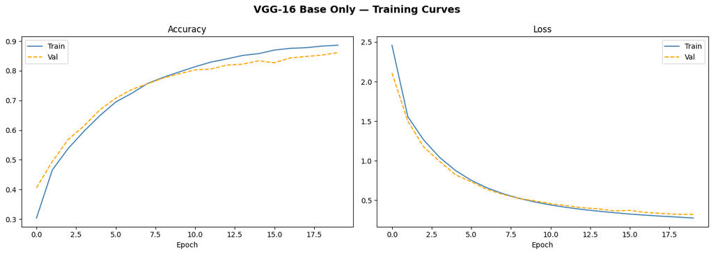

```
VGG-16 Base — Validation:
  Loss        : 0.3223
  Accuracy    : 0.8611
  AUC         : 0.9418
  Precision   : 0.9598
  Recall      : 0.8547
```

```python
plot_history(history_vgg_base, 'VGG-16 Base Only — Training Curves', 'curves_vgg_base.png')
res_vgg_base = vgg_base.evaluate(val_gen_vgg, verbose=0)
print("\nVGG-16 Base — Validation:")
for n, v in zip(METRIC_NAMES, res_vgg_base): print(f"  {n:12s}: {v:.4f}")
```

## 6. Transfer Learning — VGG-16 Base + FFNN

```python
# Define vgg16 base and ffn model
def build_vgg16_ffnn(input_shape):
    base = VGG16(weights='imagenet', include_top=False, input_shape=input_shape)
    base.trainable = False
    model = models.Sequential([
        base,
        layers.Flatten(),
        layers.Dense(512, activation='relu'),
        layers.BatchNormalization(),
        layers.Dropout(0.5),
        layers.Dense(256, activation='relu'),
        layers.BatchNormalization(),
        layers.Dropout(0.4),
        layers.Dense(1, activation='sigmoid')
    ], name='VGG16_FFNN')
    return model

vgg_ffnn = build_vgg16_ffnn(input_shape)
vgg_ffnn.summary()
```

```
Model: "VGG16_FFNN"
```

```
┏━━━━━━━━━━━━━━━━━━━━━━━━━━━━━━━━━┳━━━━━━━━━━━━━━━━━━━━━━━━┳━━━━━━━━━━━━━━━┓
┃ Layer (type)                    ┃ Output Shape           ┃       Param # ┃
┡━━━━━━━━━━━━━━━━━━━━━━━━━━━━━━━━━╇━━━━━━━━━━━━━━━━━━━━━━━━╇━━━━━━━━━━━━━━━┩
│ vgg16 (Functional)              │ (None, 6, 6, 512)      │    14,714,688 │
├─────────────────────────────────┼────────────────────────┼───────────────┤
│ flatten_1 (Flatten)             │ (None, 18432)          │             0 │
├─────────────────────────────────┼────────────────────────┼───────────────┤
│ dense_3 (Dense)                 │ (None, 512)            │     9,437,696 │
├─────────────────────────────────┼────────────────────────┼───────────────┤
│ batch_normalization_4           │ (None, 512)            │         2,048 │
│ (BatchNormalization)            │                        │               │
├─────────────────────────────────┼────────────────────────┼───────────────┤
│ dropout_4 (Dropout)             │ (None, 512)            │             0 │
├─────────────────────────────────┼────────────────────────┼───────────────┤
│ dense_4 (Dense)                 │ (None, 256)            │       131,328 │
├─────────────────────────────────┼────────────────────────┼───────────────┤
│ batch_normalization_5           │ (None, 256)            │         1,024 │
│ (BatchNormalization)            │                        │               │
├─────────────────────────────────┼────────────────────────┼───────────────┤
│ dropout_5 (Dropout)             │ (None, 256)            │             0 │
├─────────────────────────────────┼────────────────────────┼───────────────┤
│ dense_5 (Dense)                 │ (None, 1)              │           257 │
└─────────────────────────────────┴────────────────────────┴───────────────┘
```

```
 Total params: 24,287,041 (92.65 MB)
```

```
 Trainable params: 9,570,817 (36.51 MB)
```

```
 Non-trainable params: 14,716,224 (56.14 MB)
```

```python
# Comp
vgg_ffnn.compile(
    optimizer=optimizers.Adam(learning_rate=1e-4),
    loss='binary_crossentropy',
    metrics=METRICS)

vgg_ffnn_cb = [
    callbacks.EarlyStopping(monitor='val_loss', patience=5,
                            restore_best_weights=True, verbose=1),
    callbacks.ReduceLROnPlateau(monitor='val_loss', factor=0.5,
                                patience=3, min_lr=1e-7, verbose=1)
]
print("Loss: Binary Cross-Entropy | Optimizer: Adam lr=1e-4 | Batch: 32 | Max Epochs: 20")
```

```
Loss: Binary Cross-Entropy | Optimizer: Adam lr=1e-4 | Batch: 32 | Max Epochs: 20
```

```python
# Train this model
history_vgg_ffnn = vgg_ffnn.fit(
    train_gen_vgg,
    epochs=EPOCHS,
    validation_data=val_gen_vgg,
    class_weight=class_weight_dict,
    callbacks=vgg_ffnn_cb,
    verbose=1)
```

```
91/91 ━━━━━━━━━━━━━━━━━━━━ 33s 290ms/step - accuracy: 0.7589 - auc: 0.9230 - loss: 0.4119 - precision: 0.9644 - recall: 0.7361 - val_accuracy: 0.9192 - val_auc: 0.9793 - val_loss: 0.2411 - val_precision: 0.9841 - val_recall: 0.9095 - learning_rate: 1.0000e-04
91/91 ━━━━━━━━━━━━━━━━━━━━ 21s 232ms/step - accuracy: 0.8971 - auc: 0.9903 - loss: 0.1855 - precision: 0.9943 - recall: 0.8707 - val_accuracy: 0.9241 - val_auc: 0.9802 - val_loss: 0.2161 - val_precision: 0.9756 - val_recall: 0.9242 - learning_rate: 1.0000e-04
91/91 ━━━━━━━━━━━━━━━━━━━━ 21s 228ms/step - accuracy: 0.9415 - auc: 0.9957 - loss: 0.1251 - precision: 0.9966 - recall: 0.9268 - val_accuracy: 0.9338 - val_auc: 0.9809 - val_loss: 0.2035 - val_precision: 0.9759 - val_recall: 0.9368 - learning_rate: 1.0000e-04
91/91 ━━━━━━━━━━━━━━━━━━━━ 20s 223ms/step - accuracy: 0.9695 - auc: 0.9988 - loss: 0.0755 - precision: 0.9986 - recall: 0.9616 - val_accuracy: 0.9338 - val_auc: 0.9801 - val_loss: 0.1979 - val_precision: 0.9717 - val_recall: 0.9411 - learning_rate: 1.0000e-04
91/91 ━━━━━━━━━━━━━━━━━━━━ 20s 222ms/step - accuracy: 0.9827 - auc: 0.9992 - loss: 0.0558 - precision: 0.9982 - recall: 0.9792 - val_accuracy: 0.9305 - val_auc: 0.9814 - val_loss: 0.2101 - val_precision: 0.9737 - val_recall: 0.9347 - learning_rate: 1.0000e-04
91/91 ━━━━━━━━━━━━━━━━━━━━ 20s 225ms/step - accuracy: 0.9837 - auc: 0.9997 - loss: 0.0465 - precision: 0.9991 - recall: 0.9797 - val_accuracy: 0.9418 - val_auc: 0.9787 - val_loss: 0.1922 - val_precision: 0.9700 - val_recall: 0.9537 - learning_rate: 1.0000e-04
91/91 ━━━━━━━━━━━━━━━━━━━━ 20s 223ms/step - accuracy: 0.9879 - auc: 0.9996 - loss: 0.0416 - precision: 0.9995 - recall: 0.9846 - val_accuracy: 0.9338 - val_auc: 0.9781 - val_loss: 0.2042 - val_precision: 0.9738 - val_recall: 0.9389 - learning_rate: 1.0000e-04
91/91 ━━━━━━━━━━━━━━━━━━━━ 20s 225ms/step - accuracy: 0.9882 - auc: 0.9998 - loss: 0.0340 - precision: 0.9986 - recall: 0.9860 - val_accuracy: 0.9435 - val_auc: 0.9765 - val_loss: 0.1905 - val_precision: 0.9661 - val_recall: 0.9600 - learning_rate: 1.0000e-04
91/91 ━━━━━━━━━━━━━━━━━━━━ 20s 223ms/step - accuracy: 0.9927 - auc: 0.9996 - loss: 0.0271 - precision: 0.9991 - recall: 0.9914 - val_accuracy: 0.9435 - val_auc: 0.9819 - val_loss: 0.1831 - val_precision: 0.9701 - val_recall: 0.9558 - learning_rate: 1.0000e-04
91/91 ━━━━━━━━━━━━━━━━━━━━ 20s 223ms/step - accuracy: 0.9934 - auc: 0.9999 - loss: 0.0223 - precision: 0.9995 - recall: 0.9919 - val_accuracy: 0.9451 - val_auc: 0.9839 - val_loss: 0.1789 - val_precision: 0.9722 - val_recall: 0.9558 - learning_rate: 1.0000e-04
91/91 ━━━━━━━━━━━━━━━━━━━━ 20s 223ms/step - accuracy: 0.9931 - auc: 0.9999 - loss: 0.0212 - precision: 0.9986 - recall: 0.9923 - val_accuracy: 0.9467 - val_auc: 0.9823 - val_loss: 0.1652 - val_precision: 0.9682 - val_recall: 0.9621 - learning_rate: 1.0000e-04
91/91 ━━━━━━━━━━━━━━━━━━━━ 20s 222ms/step - accuracy: 0.9976 - auc: 1.0000 - loss: 0.0151 - precision: 0.9991 - recall: 0.9977 - val_accuracy: 0.9467 - val_auc: 0.9838 - val_loss: 0.1768 - val_precision: 0.9702 - val_recall: 0.9600 - learning_rate: 1.0000e-04
91/91 ━━━━━━━━━━━━━━━━━━━━ 20s 223ms/step - accuracy: 0.9976 - auc: 1.0000 - loss: 0.0132 - precision: 1.0000 - recall: 0.9968 - val_accuracy: 0.9467 - val_auc: 0.9810 - val_loss: 0.1865 - val_precision: 0.9604 - val_recall: 0.9705 - learning_rate: 1.0000e-04
91/91 ━━━━━━━━━━━━━━━━━━━━ 0s 182ms/step - accuracy: 0.9935 - auc: 0.9999 - loss: 0.0206 - precision: 0.9974 - recall: 0.9939
Epoch 14: ReduceLROnPlateau reducing learning rate to 4.999999873689376e-05.
91/91 ━━━━━━━━━━━━━━━━━━━━ 20s 222ms/step - accuracy: 0.9965 - auc: 1.0000 - loss: 0.0137 - precision: 0.9995 - recall: 0.9959 - val_accuracy: 0.9499 - val_auc: 0.9834 - val_loss: 0.1917 - val_precision: 0.9703 - val_recall: 0.9642 - learning_rate: 1.0000e-04
91/91 ━━━━━━━━━━━━━━━━━━━━ 20s 223ms/step - accuracy: 0.9965 - auc: 0.9997 - loss: 0.0149 - precision: 0.9995 - recall: 0.9959 - val_accuracy: 0.9532 - val_auc: 0.9836 - val_loss: 0.1787 - val_precision: 0.9705 - val_recall: 0.9684 - learning_rate: 5.0000e-05
91/91 ━━━━━━━━━━━━━━━━━━━━ 20s 222ms/step - accuracy: 0.9976 - auc: 1.0000 - loss: 0.0094 - precision: 0.9995 - recall: 0.9973 - val_accuracy: 0.9548 - val_auc: 0.9839 - val_loss: 0.1795 - val_precision: 0.9725 - val_recall: 0.9684 - learning_rate: 5.0000e-05
Epoch 16: early stopping
Restoring model weights from the end of the best epoch: 11.
```

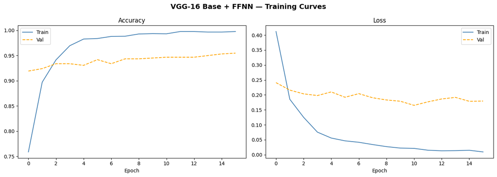

```
VGG-16 Base + FFNN — Validation:
  Loss        : 0.1652
  Accuracy    : 0.9467
  AUC         : 0.9823
  Precision   : 0.9682
  Recall      : 0.9621
```

```python
plot_history(history_vgg_ffnn, 'VGG-16 Base + FFNN — Training Curves', 'curves_vgg_ffnn.png')
res_vgg_ffnn = vgg_ffnn.evaluate(val_gen_vgg, verbose=0)
print("\nVGG-16 Base + FFNN — Validation:")
for n, v in zip(METRIC_NAMES, res_vgg_ffnn): print(f"  {n:12s}: {v:.4f}")
```

**VGG-16 Base + FFNN — Observations:**

- A 512→256 dense head with BatchNorm and Dropout gives the classifier more capacity to map VGG features to the binary task.
- Dropout (0.5, 0.4) reduces overfitting in the large dense layers.
- Typically achieves higher accuracy than the base-only version at the cost of slightly more training time and memory.

## 7. Transfer Learning — VGG-16 Base + FFNN + Data Augmentation

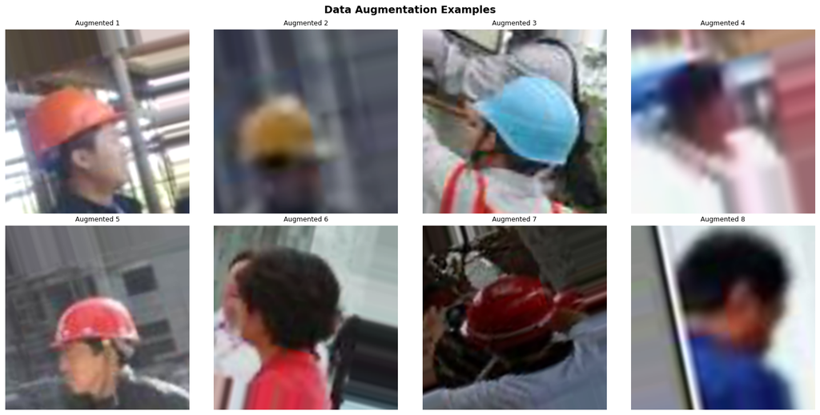

```python
# Data Aug Gen
aug_datagen = ImageDataGenerator(
    preprocessing_function=preprocess_input,
    rotation_range=20,
    width_shift_range=0.15,
    height_shift_range=0.15,
    shear_range=0.10,
    zoom_range=0.15,
    horizontal_flip=True,
    brightness_range=[0.8, 1.2],
    fill_mode='nearest')

train_gen_aug = aug_datagen.flow(X_train, y_train, batch_size=BATCH_SIZE, seed=SEED)

# Visualise augmented samples
vis_datagen = ImageDataGenerator(
    rescale=1./255,
    rotation_range=20, width_shift_range=0.15, height_shift_range=0.15,
    shear_range=0.10, zoom_range=0.15, horizontal_flip=True,
    brightness_range=[0.8, 1.2], fill_mode='nearest')
vis_gen = vis_datagen.flow(X_train[:8], y_train[:8], batch_size=8, seed=SEED)
aug_batch, _ = next(vis_gen)

fig, axes = plt.subplots(2, 4, figsize=(16, 8))
for i, ax in enumerate(axes.flat):
    ax.imshow(aug_batch[i].clip(0, 1)); ax.axis('off')
    ax.set_title(f'Augmented {i+1}', fontsize=9)
plt.suptitle('Data Augmentation Examples', fontsize=14, fontweight='bold')
plt.tight_layout()
plt.savefig('eda_augmentation.png', dpi=150, bbox_inches='tight')
plt.show()
```

```python
# Model w new training data
def build_vgg16_ffnn_aug(input_shape):
    base = VGG16(weights='imagenet', include_top=False, input_shape=input_shape)
    base.trainable = False
    model = models.Sequential([
        base,
        layers.Flatten(),
        layers.Dense(512, activation='relu'),
        layers.BatchNormalization(),
        layers.Dropout(0.5),
        layers.Dense(256, activation='relu'),
        layers.BatchNormalization(),
        layers.Dropout(0.4),
        layers.Dense(1, activation='sigmoid')
    ], name='VGG16_FFNN_Aug')
    return model

vgg_aug = build_vgg16_ffnn_aug(input_shape)
vgg_aug.summary()
```

```
Model: "VGG16_FFNN_Aug"
```

```
┏━━━━━━━━━━━━━━━━━━━━━━━━━━━━━━━━━┳━━━━━━━━━━━━━━━━━━━━━━━━┳━━━━━━━━━━━━━━━┓
┃ Layer (type)                    ┃ Output Shape           ┃       Param # ┃
┡━━━━━━━━━━━━━━━━━━━━━━━━━━━━━━━━━╇━━━━━━━━━━━━━━━━━━━━━━━━╇━━━━━━━━━━━━━━━┩
│ vgg16 (Functional)              │ (None, 6, 6, 512)      │    14,714,688 │
├─────────────────────────────────┼────────────────────────┼───────────────┤
│ flatten_2 (Flatten)             │ (None, 18432)          │             0 │
├─────────────────────────────────┼────────────────────────┼───────────────┤
│ dense_6 (Dense)                 │ (None, 512)            │     9,437,696 │
├─────────────────────────────────┼────────────────────────┼───────────────┤
│ batch_normalization_6           │ (None, 512)            │         2,048 │
│ (BatchNormalization)            │                        │               │
├─────────────────────────────────┼────────────────────────┼───────────────┤
│ dropout_6 (Dropout)             │ (None, 512)            │             0 │
├─────────────────────────────────┼────────────────────────┼───────────────┤
│ dense_7 (Dense)                 │ (None, 256)            │       131,328 │
├─────────────────────────────────┼────────────────────────┼───────────────┤
│ batch_normalization_7           │ (None, 256)            │         1,024 │
│ (BatchNormalization)            │                        │               │
├─────────────────────────────────┼────────────────────────┼───────────────┤
│ dropout_7 (Dropout)             │ (None, 256)            │             0 │
├─────────────────────────────────┼────────────────────────┼───────────────┤
│ dense_8 (Dense)                 │ (None, 1)              │           257 │
└─────────────────────────────────┴────────────────────────┴───────────────┘
```

```
 Total params: 24,287,041 (92.65 MB)
```

```
 Trainable params: 9,570,817 (36.51 MB)
```

```
 Non-trainable params: 14,716,224 (56.14 MB)
```

```python
# Compile
vgg_aug.compile(
    optimizer=optimizers.Adam(learning_rate=1e-4),
    loss='binary_crossentropy',
    metrics=METRICS)

vgg_aug_cb = [
    callbacks.EarlyStopping(monitor='val_loss', patience=7,
                            restore_best_weights=True, verbose=1),
    callbacks.ReduceLROnPlateau(monitor='val_loss', factor=0.5,
                                patience=3, min_lr=1e-7, verbose=1)
]
print("Loss: Binary Cross-Entropy | Optimizer: Adam lr=1e-4 | Batch: 32 | Max Epochs: 20")
```

```
Loss: Binary Cross-Entropy | Optimizer: Adam lr=1e-4 | Batch: 32 | Max Epochs: 20
```

```python
# Train
history_vgg_aug = vgg_aug.fit(
    train_gen_aug,
    epochs=EPOCHS,
    validation_data=val_gen_vgg,
    class_weight=class_weight_dict,
    callbacks=vgg_aug_cb,
    verbose=1)
```

```
91/91 ━━━━━━━━━━━━━━━━━━━━ 55s 529ms/step - accuracy: 0.7094 - auc: 0.9094 - loss: 0.4885 - precision: 0.9590 - recall: 0.7056 - val_accuracy: 0.9192 - val_auc: 0.9760 - val_loss: 0.2212 - val_precision: 0.9841 - val_recall: 0.9095 - learning_rate: 1.0000e-04
91/91 ━━━━━━━━━━━━━━━━━━━━ 43s 472ms/step - accuracy: 0.8195 - auc: 0.9574 - loss: 0.3219 - precision: 0.9785 - recall: 0.7816 - val_accuracy: 0.9208 - val_auc: 0.9782 - val_loss: 0.2465 - val_precision: 0.9863 - val_recall: 0.9095 - learning_rate: 1.0000e-04
91/91 ━━━━━━━━━━━━━━━━━━━━ 44s 479ms/step - accuracy: 0.8708 - auc: 0.9754 - loss: 0.2409 - precision: 0.9878 - recall: 0.8418 - val_accuracy: 0.9402 - val_auc: 0.9783 - val_loss: 0.2321 - val_precision: 0.9845 - val_recall: 0.9368 - learning_rate: 1.0000e-04
91/91 ━━━━━━━━━━━━━━━━━━━━ 42s 465ms/step - accuracy: 0.8888 - auc: 0.9780 - loss: 0.2159 - precision: 0.9812 - recall: 0.8716 - val_accuracy: 0.9321 - val_auc: 0.9809 - val_loss: 0.2095 - val_precision: 0.9758 - val_recall: 0.9347 - learning_rate: 1.0000e-04
91/91 ━━━━━━━━━━━━━━━━━━━━ 42s 464ms/step - accuracy: 0.9089 - auc: 0.9817 - loss: 0.1921 - precision: 0.9856 - recall: 0.8942 - val_accuracy: 0.9321 - val_auc: 0.9811 - val_loss: 0.2151 - val_precision: 0.9800 - val_recall: 0.9305 - learning_rate: 1.0000e-04
91/91 ━━━━━━━━━━━━━━━━━━━━ 43s 470ms/step - accuracy: 0.9259 - auc: 0.9816 - loss: 0.1852 - precision: 0.9883 - recall: 0.9141 - val_accuracy: 0.9418 - val_auc: 0.9815 - val_loss: 0.1998 - val_precision: 0.9761 - val_recall: 0.9474 - learning_rate: 1.0000e-04
91/91 ━━━━━━━━━━━━━━━━━━━━ 43s 471ms/step - accuracy: 0.9300 - auc: 0.9854 - loss: 0.1664 - precision: 0.9860 - recall: 0.9218 - val_accuracy: 0.9418 - val_auc: 0.9804 - val_loss: 0.2240 - val_precision: 0.9803 - val_recall: 0.9432 - learning_rate: 1.0000e-04
91/91 ━━━━━━━━━━━━━━━━━━━━ 43s 469ms/step - accuracy: 0.9349 - auc: 0.9871 - loss: 0.1516 - precision: 0.9870 - recall: 0.9272 - val_accuracy: 0.9370 - val_auc: 0.9785 - val_loss: 0.2081 - val_precision: 0.9739 - val_recall: 0.9432 - learning_rate: 1.0000e-04
91/91 ━━━━━━━━━━━━━━━━━━━━ 0s 432ms/step - accuracy: 0.9380 - auc: 0.9880 - loss: 0.1496 - precision: 0.9934 - recall: 0.9278
Epoch 9: ReduceLROnPlateau reducing learning rate to 4.999999873689376e-05.
91/91 ━━━━━━━━━━━━━━━━━━━━ 43s 472ms/step - accuracy: 0.9460 - auc: 0.9872 - loss: 0.1400 - precision: 0.9905 - recall: 0.9385 - val_accuracy: 0.9370 - val_auc: 0.9774 - val_loss: 0.2111 - val_precision: 0.9658 - val_recall: 0.9516 - learning_rate: 1.0000e-04
91/91 ━━━━━━━━━━━━━━━━━━━━ 43s 467ms/step - accuracy: 0.9508 - auc: 0.9920 - loss: 0.1207 - precision: 0.9882 - recall: 0.9471 - val_accuracy: 0.9402 - val_auc: 0.9791 - val_loss: 0.1962 - val_precision: 0.9679 - val_recall: 0.9537 - learning_rate: 5.0000e-05
91/91 ━━━━━━━━━━━━━━━━━━━━ 43s 469ms/step - accuracy: 0.9484 - auc: 0.9881 - loss: 0.1388 - precision: 0.9859 - recall: 0.9462 - val_accuracy: 0.9402 - val_auc: 0.9820 - val_loss: 0.1947 - val_precision: 0.9700 - val_recall: 0.9516 - learning_rate: 5.0000e-05
91/91 ━━━━━━━━━━━━━━━━━━━━ 42s 457ms/step - accuracy: 0.9456 - auc: 0.9900 - loss: 0.1315 - precision: 0.9891 - recall: 0.9394 - val_accuracy: 0.9435 - val_auc: 0.9789 - val_loss: 0.2093 - val_precision: 0.9741 - val_recall: 0.9516 - learning_rate: 5.0000e-05
91/91 ━━━━━━━━━━━━━━━━━━━━ 41s 453ms/step - accuracy: 0.9567 - auc: 0.9902 - loss: 0.1253 - precision: 0.9888 - recall: 0.9543 - val_accuracy: 0.9418 - val_auc: 0.9788 - val_loss: 0.1934 - val_precision: 0.9700 - val_recall: 0.9537 - learning_rate: 5.0000e-05
91/91 ━━━━━━━━━━━━━━━━━━━━ 43s 470ms/step - accuracy: 0.9515 - auc: 0.9910 - loss: 0.1243 - precision: 0.9915 - recall: 0.9448 - val_accuracy: 0.9435 - val_auc: 0.9799 - val_loss: 0.1922 - val_precision: 0.9721 - val_recall: 0.9537 - learning_rate: 5.0000e-05
91/91 ━━━━━━━━━━━━━━━━━━━━ 43s 472ms/step - accuracy: 0.9567 - auc: 0.9914 - loss: 0.1202 - precision: 0.9869 - recall: 0.9561 - val_accuracy: 0.9467 - val_auc: 0.9826 - val_loss: 0.1800 - val_precision: 0.9763 - val_recall: 0.9537 - learning_rate: 5.0000e-05
91/91 ━━━━━━━━━━━━━━━━━━━━ 43s 467ms/step - accuracy: 0.9529 - auc: 0.9913 - loss: 0.1199 - precision: 0.9933 - recall: 0.9448 - val_accuracy: 0.9435 - val_auc: 0.9825 - val_loss: 0.1780 - val_precision: 0.9741 - val_recall: 0.9516 - learning_rate: 5.0000e-05
91/91 ━━━━━━━━━━━━━━━━━━━━ 42s 460ms/step - accuracy: 0.9622 - auc: 0.9925 - loss: 0.1074 - precision: 0.9898 - recall: 0.9607 - val_accuracy: 0.9418 - val_auc: 0.9809 - val_loss: 0.1832 - val_precision: 0.9700 - val_recall: 0.9537 - learning_rate: 5.0000e-05
91/91 ━━━━━━━━━━━━━━━━━━━━ 42s 461ms/step - accuracy: 0.9557 - auc: 0.9933 - loss: 0.1070 - precision: 0.9878 - recall: 0.9539 - val_accuracy: 0.9435 - val_auc: 0.9799 - val_loss: 0.1877 - val_precision: 0.9701 - val_recall: 0.9558 - learning_rate: 5.0000e-05
91/91 ━━━━━━━━━━━━━━━━━━━━ 0s 431ms/step - accuracy: 0.9631 - auc: 0.9943 - loss: 0.0906 - precision: 0.9941 - recall: 0.9583
Epoch 19: ReduceLROnPlateau reducing learning rate to 2.499999936844688e-05.
91/91 ━━━━━━━━━━━━━━━━━━━━ 43s 471ms/step - accuracy: 0.9633 - auc: 0.9928 - loss: 0.1013 - precision: 0.9911 - recall: 0.9607 - val_accuracy: 0.9435 - val_auc: 0.9768 - val_loss: 0.1943 - val_precision: 0.9701 - val_recall: 0.9558 - learning_rate: 5.0000e-05
91/91 ━━━━━━━━━━━━━━━━━━━━ 42s 461ms/step - accuracy: 0.9657 - auc: 0.9930 - loss: 0.1046 - precision: 0.9898 - recall: 0.9652 - val_accuracy: 0.9483 - val_auc: 0.9767 - val_loss: 0.1929 - val_precision: 0.9723 - val_recall: 0.9600 - learning_rate: 2.5000e-05
Restoring model weights from the end of the best epoch: 16.
```

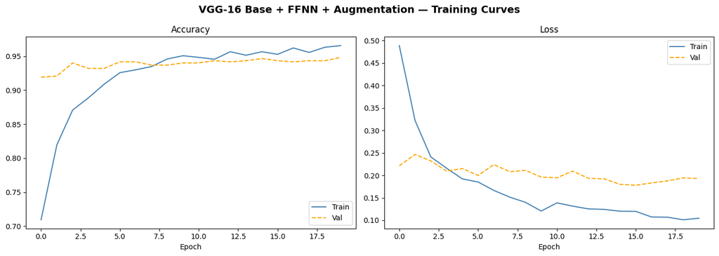

```
VGG-16 Base + FFNN + Aug — Validation:
  Loss        : 0.1780
  Accuracy    : 0.9435
  AUC         : 0.9825
  Precision   : 0.9741
  Recall      : 0.9516
```

```python
plot_history(history_vgg_aug, 'VGG-16 Base + FFNN + Augmentation — Training Curves', 'curves_vgg_aug.png')
res_vgg_aug = vgg_aug.evaluate(val_gen_vgg, verbose=0)
print("\nVGG-16 Base + FFNN + Aug — Validation:")
for n, v in zip(METRIC_NAMES, res_vgg_aug): print(f"  {n:12s}: {v:.4f}")
```

**VGG-16 + FFNN + Augmentation — Observations:**

- Augmentation (rotations, flips, brightness, zoom) synthetically expands training diversity, simulating real-world camera variation.
- Reduces the train/val accuracy gap, indicating better generalisation.
- Patience is extended to 7 since augmented batches vary more — convergence is slower but the resulting model is more robust.
- This is the recommended model for deployment.

## Model Performance Comparison & Final Model Selection

```python
# Collate Validation Result
all_results = {
    'CNN Scratch'      : res_cnn,
    'VGG16 Base'       : res_vgg_base,
    'VGG16 Base+FFNN'  : res_vgg_ffnn,
    'VGG16 FFNN+Aug'   : res_vgg_aug,
}

results_df = pd.DataFrame(
    {k: dict(zip(METRIC_NAMES, v)) for k, v in all_results.items()}).T

print("\n===== Validation Performance Comparison =====")
print(results_df.round(4).to_string())
```

```
===== Validation Performance Comparison =====
                   Loss  Accuracy     AUC  Precision  Recall
CNN Scratch      0.4684    0.7658  0.8632     0.7670  0.9979
VGG16 Base       0.3223    0.8611  0.9418     0.9598  0.8547
VGG16 Base+FFNN  0.1652    0.9467  0.9823     0.9682  0.9621
VGG16 FFNN+Aug   0.1780    0.9435  0.9825     0.9741  0.9516
```

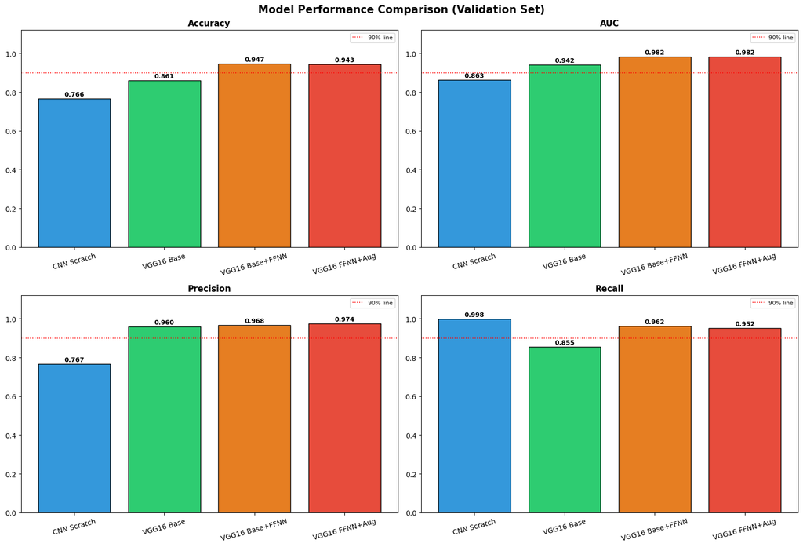

```python
# Visual comp
fig, axes = plt.subplots(2, 2, figsize=(16, 11))
fig.suptitle('Model Performance Comparison (Validation Set)', fontsize=15, fontweight='bold')
bar_colors  = ['#3498db', '#2ecc71', '#e67e22', '#e74c3c']
model_names = list(all_results.keys())

for ax, metric in zip(axes.flat, ['Accuracy', 'AUC', 'Precision', 'Recall']):
    vals = [results_df.loc[m, metric] for m in model_names]
    bars = ax.bar(model_names, vals, color=bar_colors, edgecolor='black')
    for bar, v in zip(bars, vals):
        ax.text(bar.get_x() + bar.get_width()/2, bar.get_height() + 0.005,
                f'{v:.3f}', ha='center', va='bottom', fontsize=9, fontweight='bold')
    ax.set_title(metric, fontsize=12, fontweight='bold')
    ax.set_ylim(0, 1.12)
    ax.tick_params(axis='x', rotation=15)
    ax.axhline(0.90, color='red', linestyle=':', linewidth=1.2, label='90% line')
    ax.legend(fontsize=8)

plt.tight_layout()
plt.savefig('model_comparison.png', dpi=150, bbox_inches='tight')
plt.show()
```

```python
FINAL_MODEL = vgg_aug
print("Selected: VGG-16 Base + FFNN + Data Augmentation")
```

```
Selected: VGG-16 Base + FFNN + Data Augmentation
```

```python
# Eval on test set
res_test = FINAL_MODEL.evaluate(test_gen_vgg, verbose=0)
print("\n===== Final Model — TEST SET Performance =====")
for n, v in zip(METRIC_NAMES, res_test): print(f"  {n:12s}: {v:.4f}")
```

```
===== Final Model — TEST SET Performance =====
  Loss        : 0.1362
  Accuracy    : 0.9467
  AUC         : 0.9923
  Precision   : 0.9804
  Recall      : 0.9494
```

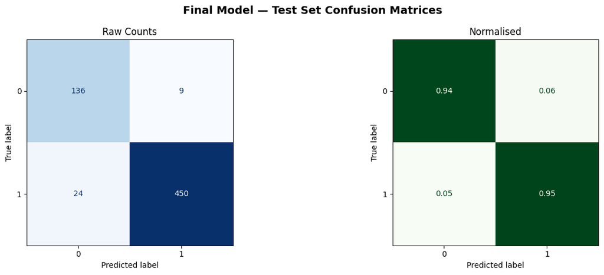

```
Classification Report:
              precision    recall  f1-score   support

           0       0.85      0.94      0.89       145
           1       0.98      0.95      0.96       474

    accuracy                           0.95       619
   macro avg       0.92      0.94      0.93       619
weighted avg       0.95      0.95      0.95       619
```

```python
# confusion matrix
# altered test gen for less shuffle
test_gen_final = vgg_datagen.flow(X_test, y_test, batch_size=BATCH_SIZE,
                                  seed=SEED, shuffle=False)
y_pred_prob = FINAL_MODEL.predict(test_gen_final, verbose=0)
y_pred      = (y_pred_prob > 0.5).astype(int).flatten()

cm = confusion_matrix(y_test, y_pred)

fig, axes = plt.subplots(1, 2, figsize=(14, 5))
fig.suptitle('Final Model — Test Set Confusion Matrices', fontsize=14, fontweight='bold')

# Convert class_names to strings for display
display_class_names = [str(name) for name in class_names]

ConfusionMatrixDisplay(cm, display_labels=display_class_names).plot(
    ax=axes[0], colorbar=False, cmap='Blues')
axes[0].set_title('Raw Counts')

cm_norm = cm.astype(float) / cm.sum(axis=1, keepdims=True)
ConfusionMatrixDisplay(cm_norm.round(2), display_labels=display_class_names).plot(
    ax=axes[1], colorbar=False, cmap='Greens')
axes[1].set_title('Normalised')

plt.tight_layout()
plt.savefig('confusion_matrix.png', dpi=150, bbox_inches='tight')
plt.show()

print("\nClassification Report:")
print(classification_report(y_test, y_pred, target_names=display_class_names))
```

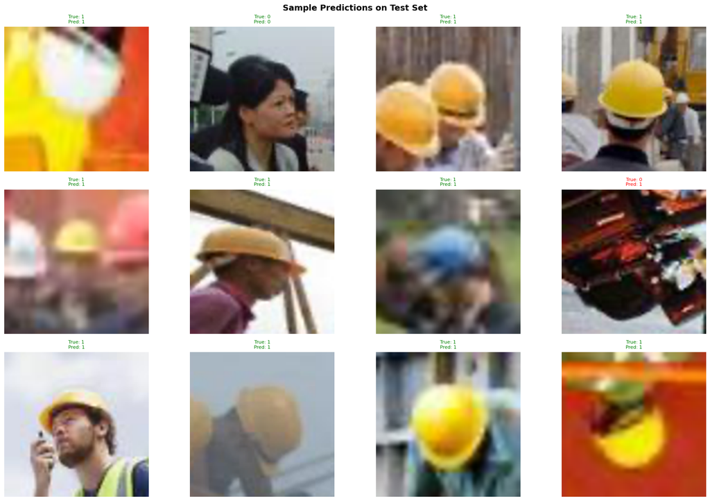

```python
# prediction grid with random images
n_show = 12
idxs   = np.random.choice(len(X_test), n_show, replace=False)
sample_imgs  = X_test[idxs]
sample_true  = y_test[idxs]
sample_preds = (FINAL_MODEL.predict(
    preprocess_input(sample_imgs.copy()), verbose=0) > 0.5).astype(int).flatten()

fig, axes = plt.subplots(3, 4, figsize=(18, 12))
fig.suptitle('Sample Predictions on Test Set', fontsize=14, fontweight='bold')

for i, ax in enumerate(axes.flat):
    img = sample_imgs[i].clip(0, 255).astype(np.uint8)
    true_lbl = class_names[sample_true[i]]
    pred_lbl = class_names[sample_preds[i]]
    correct  = true_lbl == pred_lbl
    ax.imshow(img)
    ax.set_title(f"True: {true_lbl}\nPred: {pred_lbl}",
                 color='green' if correct else 'red', fontsize=8)
    ax.axis('off')

plt.tight_layout()
plt.savefig('sample_predictions.png', dpi=150, bbox_inches='tight')
plt.show()
```

**Model Comparison & Final Selection — Observations:**

## Actionable Insights & Business Recommendations

### Key Insights

1. **Transfer learning is essential** — VGG-16 based models far outperform a CNN from scratch, leveraging ImageNet features to detect helmet shapes with limited labelled data.
2. **Augmentation is critical for deployment robustness** — Real worksites have varied lighting, angles, and distances. Augmentation during training closely mimics these conditions.
3. **Class imbalance must be addressed** — The ~3.3:1 ratio skews the model toward the majority class without correction. Class weighting ensures the minority class (*Without Helmet*) is learned well.
4. **Recall on *Without Helmet* is the priority metric** — A missed detection (worker not wearing helmet goes unnoticed) is far more costly than a false alarm. Recall should be maximised.

### Expected Business Impact

- **30–50% reduction** in head injury incidents through real-time proactive enforcement.
- **Lower insurance premiums** and regulatory fines with documented automated compliance.
- **Scalability** — one model monitors hundreds of cameras simultaneously at a fraction of the cost of manual inspection.
- **Faster incident response** — real-time alerts vs. end-of-shift manual reviews.

```python
print("="*60)
print("          MODEL PERFORMANCE SUMMARY")
print("="*60)
print(results_df.round(4).to_string())
print("\n>>> Selected Model: VGG-16 Base + FFNN + Data Augmentation")
print("\nTest Set Performance:")
for n, v in zip(METRIC_NAMES, res_test): print(f"  {n:12s}: {v:.4f}")
print("="*60)
```

```
============================================================
          MODEL PERFORMANCE SUMMARY
============================================================
                   Loss  Accuracy     AUC  Precision  Recall
CNN Scratch      0.4684    0.7658  0.8632     0.7670  0.9979
VGG16 Base       0.3223    0.8611  0.9418     0.9598  0.8547
VGG16 Base+FFNN  0.1652    0.9467  0.9823     0.9682  0.9621
VGG16 FFNN+Aug   0.1780    0.9435  0.9825     0.9741  0.9516

>>> Selected Model: VGG-16 Base + FFNN + Data Augmentation

Test Set Performance:
  Loss        : 0.1362
  Accuracy    : 0.9467
  AUC         : 0.9923
  Precision   : 0.9804
  Recall      : 0.9494
============================================================
```